# Analiza wytwarzania energii w elektrownii słonecznej

Krzysztof Olejniczak

07 styczeń, 2018

## Spis treści

1. Podsumowanie badań
2. Wczytanie bibliotek
3. Powtarzalność danych
4. Wczytanie danych
5. Przetwarzanie brakujących danych
6. Codebook
7. Podsumowanie zbioru i podstawowe statystyki
   - Ilość atrybutów zbioru
   - Liczba rekordów
   - Liczba elektrowni
   - Niepowtarzalna liczba lokalizacji
   - Mapa prezentująca prawdopodobne lokalizacje elektrowni
   - Liczba producentów elektrowni
   - Liczba modeli elektrowni
   - Rozważany przedział czasowy
   - Przedział godzin w ciągu dnia
   - Podsumowanie wartości atrybutów
   - Początek zbioru
8. Szczegółowa analiza wartości atrybutów - wykresy rozkładu wartości atrybutów
   - Dane techniczne elektrowni
   - Lokalizacja elektrowni
   - Czas pomiaru
   - Dane pogodowe w momencie pomiaru
   - Wartości parametru statystycznego Morana I danych pogodowych w momencie pomiaru
   - Parametry słońca w momencie pomiaru
   - Wartości parametru statystycznego Morana I parametrów słońca w momencie pomiaru
   - Parametry pcnm_norm_X
   - Wartość wytwarzanej energii
9. Wykres obrazujący wytwarzaną energię w czasie w każdej elektrowni
10. Korelacje między zmiennymi
    - Tabele korelacji między atrybutami w zbiorze danych
    - Wykresy korelacji atrybutów z energy_kwh_norm
11. Zmiana wytwarzanej energii w czasie i przestrzeni
12. Tworzenie regresora
    - Wynik regresji na danych testowych
    - Parametry oceny regresji
    - Wykresy ważności atrybutów wykorzystanych w predykcji

## 1. Podsumowanie badań

Celem projektu było stworzenie regresora, którego zadaniem jest przewidywanie energii wytwarzanej przez 17 elektrowni słonecznych we Włoszech.

W otrzymanym zbiorze danych możemy znaleźć tabelę z wynikami pomiarów czujników umieszczonych przy badanych elektrowniach. Atrybuty możemy podzielić na identyfikator, dane techniczne elektrowni, informacje o lokalizacji elektrowni, czas pomiaru, dane pogodowe oraz parametry słońca wraz z ich wartościami parametru statystycznego Morana I, wektory PCNM oraz wartość wytwarzanej energii. Dla większej czytelności raportu nazwy atrybutów zostały zmienione na angielskie w ramach jednej konwencji nazewniczej.

Część danych wejściowych z czujników na wejściu była niepoprawna i należało je poprawić. Gdy występowały w małym przedziale czasu to korekcja polegała na obliczeniu średniej z ostatniego dnia przed awarią oraz pierwszego po awarii. W przypadku dłuższej usterki to następowało kopiowane danych z innej elektrowni o podobnych parametrach. Najwięcej błędny pomiarów znaleziono w wierszach gdzie id_location=10 data=1.08-31.12.2012, id_location=3 data=1.01-31.03.2012 oraz w kolumnie sun_radiation_norm. Poprawianie danych następowało tylko w zbiorze uczącym.

Największe korelacje z wartością wytwarzanej energii można było zaobserwować dla pomiarów dotyczących słońca oraz ich parametrów statystycznych Morana I.

Za dane uczące przyjęto 2012 rok, natomiast dane testowe pochodzą z roku 2013. Generowanie regresora random foreset z trzema drzewami trwało 3,5 godziny.

Zdecydowanie najważniejszymi atrybutami do przewidzenia wytwarzania energii okazały się parametry słońca: azimuth_norm, sun_radiation_norm, altitude_norm oraz irradiating_norm. Istotny wpływ na działanie klasyfikatora miały również atrybuty pogody oraz czasu: day_of_year_norm, wind_speed_norm oraz cloud_cover_norm. Sortowanie danych poprawiło jakość regresji.

Mały wpływ na wynik regresji mają atrybuty związane z: lokalizacją elektrowni, większość parametrów elektrowni oraz większość parametrów pogody, zarówno wartości jak i ich parametry statystyczne Morana I.

## 2. Wczytanie bibliotek

Poniżej zestawienie wykorzystanych bibiotek. Biblioteka ggplot2 oraz gganimate zostały wykorzystane do rysowania wykresów, dplyr do przetwarzania danych, knitr do rysowania tabel, przy pomocy biblioteki caret został stworzony i przetestowany regresor, nastomiast biblioteki kableExtra oraz formattable umożliwiły utworzenie kolorowego wykresu korelacji.

```r
  library(ggplot2)
  library(gganimate)
  library(dplyr)
  library(knitr)
  library(caret)
  library(kableExtra)
  library(formattable)
```

## 3. Powtarzalność danych

Zadaniem poniższego kodu jest zapewnienie powtarzalności wyników przy każdym uruchomieniu programu.

```r
  set.seed(3277)
```

## 4. Wczytanie danych

Poniższy blok wczytuje dane które będą przetwarzane.

```r
  df <- data.frame(read.csv('elektrownie.csv'))
```

Następnie następuje zmiana nazw kolumn na bardziej czytelne (szczegóły w code booku).

```r
  oldColNames <- c("id", "idsito", "idmodel", "idbrand", "lat", "lon", "ageinmonths", "anno", "day", "ora", "data",
                   "temperatura_ambiente", "irradiamento", "pressure", "windspeed", "humidity", "icon", "dewpoint",
                   "windbearing", "cloudcover", "tempi", "irri", "pressurei", "windspeedi", "humidityi", "dewpointi",
                   "windbearingi", "cloudcoveri", "dist", "altitude", "azimuth", "altitudei", "azimuthi", "pcnm1",
                   "pcnm2", "pcnm3", "pcnm4", "pcnm5", "pcnm6", "pcnm7", "pcnm8", "pcnm9", "pcnm10", "pcnm11",
                   "pcnm12", "pcnm13", "pcnm14", "pcnm15", "irr_pvgis_mod", "irri_pvgis_mod", "kwh")
  newColNames <- c("id", "id_location", "id_model_norm", "id_brand_norm", "latitude_norm", "longitude_norm",
                   "age_in_months_norm", "year", "day_of_year_norm", "hour_of_day_norm", "date_time",
                   "avg_ambient_temperature_norm", "irradiating_norm", "pressure_norm", "wind_speed_norm",
                   "humidity_norm", "icon_norm", "dew_point_norm", "wind_direction_norm", "cloud_cover_norm",
                   "avg_ambient_temperature_i_norm", "irradiating_i_norm", "pressure_i_norm", "wind_speed_i_norm",
                   "humidity_i_norm", "dew_point_i_norm", "wind_direction_i_norm", "cloud_cover_i_norm", "season_norm",
                   "altitude_norm", "azimuth_norm", "altitude_i_norm", "azimuth_i_norm", "pcnm_norm_1", "pcnm_norm_2",
                   "pcnm_norm_3", "pcnm_norm_4", "pcnm_norm_5", "pcnm_norm_6", "pcnm_norm_7", "pcnm_norm_8",
                   "pcnm_norm_9", "pcnm_norm_10", "pcnm_norm_11", "pcnm_norm_12", "pcnm_norm_13", "pcnm_norm_14",
                   "pcnm_norm_15", "sun_radiation_norm", "sun_radiation_i_norm", "energy_kwh_norm")
  colnames(df)[which(colnames(df) %in% oldColNames )] <- newColNames
```

```r
  df$id_location <- round(df$id_location * 40, 0)
```

Dodane są również trzy kolejne kolumny - data w formacie posix oraz współrzędne wyskalowane na potrzeby wykresu animowanego

```r
  df$date_posix <- as.POSIXct(gsub("/","-",df$date_time),format="%m-%d-%Y %H:%M",tz="GMT")
  df$longitude_for_animated_plot <- df$longitude_norm
  df$latitude_for_animated_plot <- df$latitude_norm
  df$longitude_for_animated_plot[df$id_location==15 | df$id_location==16] <- df$longitude_for_animated_plot[df$id_location==15 | df$id_location==16] - 0.38
  df$latitude_for_animated_plot[df$id_location==15 | df$id_location==16] <- df$latitude_for_animated_plot[df$id_location==15 | df$id_location==16] - 0.095
  df$longitude_for_animated_plot[df$id_location==0] <- df$longitude_for_animated_plot[df$id_location==0] - 0.05
  df$longitude_for_animated_plot[df$id_location==1] <- df$longitude_for_animated_plot[df$id_location==1] - 0.1
  df$longitude_for_animated_plot[df$id_location==2] <- df$longitude_for_animated_plot[df$id_location==2] - 0.15
  df$longitude_for_animated_plot[df$id_location==3] <- df$longitude_for_animated_plot[df$id_location==3] - 0.2
  df$longitude_for_animated_plot[df$id_location==4] <- df$longitude_for_animated_plot[df$id_location==4] - 0.1
  df$longitude_for_animated_plot[df$id_location==8] <- df$longitude_for_animated_plot[df$id_location==8] + 0.1
  df$longitude_for_animated_plot[df$id_location==9] <- df$longitude_for_animated_plot[df$id_location==9] + 0.2
  df$longitude_for_animated_plot[df$id_location==10] <- df$longitude_for_animated_plot[df$id_location==10] - 0.1
  df$longitude_for_animated_plot[df$id_location==11] <- df$longitude_for_animated_plot[df$id_location==11] - 0.2
  df$longitude_for_animated_plot[df$id_location==13] <- df$longitude_for_animated_plot[df$id_location==13] + 0.1
```

Następnie dane są sortowane względem daty oraz identyfikatora lokalizacji elektrowni.

```r
  df <- arrange(df, id_location, date_posix)
```

## 5. Przetwarzanie brakujących danych

Z powodu różnych zdarzeń losowych np. awarii czujników dane wejściowe są częściowo niepoprawne. Aby to naprawić skorzystano z następujących technik:

- zmiana niepoprawnych danych na wzięte z elektrowni, która nie uległa awarii, a których parametry różnią się nieznacznie
- obliczanie wartości średniej pomiaru bezpośrednio przed i po awarii i zapisanie w miejsce niepoprawnych danych

Korygowane są dane tylko na potrzeby zbioru uczącego.

Dla elektrowni gdzie id_location = 5, 4, 11, 6 oraz 14 parametr age_in_months_norm = 0 jednak ciężko to naprawić gdyż brak informacji na temat ich wieku (zero mogłoby oznaczać nowo wybudowane elektrownie, jednak z danych wiadomo że ich miminalny wiek to 24 miesiące - wartość zero mogłaby wynikać tylko z błędu zaokrąglenia)

Dla elektrowni gdzie id_location = 12, 15 i 16 dane pressure_norm są nietypowe, ale prawdopodobnie ze względu na położenie nad morzem i mocne oddalenie od innych dane prawdopodobnie są poprawne.

Poniżej poprawianie wartości day_of_year gdzie id_location=2, 4, 5, 6, 10, 11, 13, 14, 15 i 16, dane przepisano z elektrowni id_location=8

```r
  for (id_loc in c(2,4,5,6,10,11,13,14,15,16)) {
    df$day_of_year_norm[df$id_location==id_loc] <- df$day_of_year_norm[df$id_location==8]
  }
```

Następnie w podobny sposób poprawiona została wartość season_norm (w id_location=4, 5, 6, 10, 11, 13, 15 i 16, przepisano z id_location=8)

```r
  for (id_loc in c(4,5,6,10,11,13,15,16)) {
    df$season_norm[df$id_location==id_loc] <- df$season_norm[df$id_location==8]
  }
```

Wartości sun_radiation_norm poprawione w różnych elektrowniach w różnych przedziałach czasowych są poprzez obliczoną średnią z przed awarii i po

```r
  corr_id_loc <- c(1,2,3,5,6,8,10,11,12,14,15,16,17)
  corr_dates_from <- c("2012-03-01 1:00","2012-07-01 1:00","2012-10-01 1:00","2012-02-01 1:00","2012-07-01 1:00",
                       "2012-12-01 1:00","2012-03-02 1:00","2012-07-01 1:00","2012-10-01 1:00","2012-01-01 1:00",
                       "2012-05-01 1:00","2012-09-01 1:00","2012-12-01 1:00")
  corr_dates_to <- c("2012-03-31 23:00","2012-07-31 23:00","2012-10-31 23:00","2012-03-01 23:00","2012-07-31 23:00",
                     "2012-12-31 23:00","2012-04-01 23:00","2012-07-31 23:00","2012-10-31 23:00","2012-01-31 23:00",
                     "2012-05-31 23:00","2012-09-30 23:00","2012-12-31 23:00")
  corr_get_dates_from <- c("2012-02-28","2012-06-30","2012-09-30","2012-01-31","2012-06-30",
                           "2012-11-30","2012-03-01","2012-06-30","2012-09-30","2013-12-30",
                           "2013-04-30","2013-08-31","2013-11-30")
  corr_get_dates_to <- c("2012-04-01","2012-08-01","2012-11-01","2012-03-02","2012-08-01",
                         "2013-01-01","2012-04-02","2012-08-01","2012-11-01","2012-02-01",
                         "2012-06-01","2012-10-01","2012-01-01")
  for (i in c(1:length(corr_id_loc))) {
    df$sun_radiation_norm[df$id_location==corr_id_loc[i] &
                          as.POSIXct(corr_dates_from[i]) <= df$date_posix &
                          df$date_posix <= as.POSIXct(corr_dates_to[i])] <-
                mean(select(filter(df,id_location==corr_id_loc[i] &
                          (as.character(df$date_posix,format="%Y-%m-%d") == corr_get_dates_from[i] |
                          as.character(df$date_posix,format="%Y-%m-%d") == corr_get_dates_to[i])),sun_radiation_norm)$sun_radiation_norm)
    df$sun_radiation_i_norm[df$id_location==corr_id_loc[i] &
                          as.POSIXct(corr_dates_from[i]) <= df$date_posix &
                          df$date_posix <= as.POSIXct(corr_dates_to[i])] <-
                mean(select(filter(df,id_location==corr_id_loc[i] &
                          (as.character(df$date_posix,format="%Y-%m-%d") == corr_get_dates_from[i] |
                           as.character(df$date_posix,format="%Y-%m-%d") == corr_get_dates_to[i])),sun_radiation_i_norm)$sun_radiation_i_norm)
  }
```

Następnie poprawiane są atrybuty id_location=10 w okresie od 2012-08-01 do 2012-12-31. Wartości są pobierane z id_location==9

```r
  corr_fields_0.25 <- c("irradiating_norm","avg_ambient_temperature_norm","pressure_norm",
                        "wind_speed_norm","humidity_norm", "dew_point_norm",
                        "wind_direction_norm","cloud_cover_norm", "irradiating_i_norm",
                        "avg_ambient_temperature_i_norm","pressure_i_norm","wind_speed_i_norm",
                        "humidity_i_norm", "dew_point_i_norm","wind_direction_i_norm",
                        "cloud_cover_i_norm","sun_radiation_norm","altitude_norm","azimuth_norm",
                        "sun_radiation_i_norm","altitude_i_norm","azimuth_i_norm", "energy_kwh_norm")
  for (i in c(1:length(corr_fields_0.25))) {
    df[df$id_location==10 &
                       as.POSIXct("2012-08-01 1:00") <= df$date_posix &
                       df$date_posix <= as.POSIXct("2012-12-31 23:00"),corr_fields_0.25[i]] <-
                  df[df$id_location==9 &
                       as.POSIXct("2012-08-01 1:00") <= df$date_posix &
                       df$date_posix <= as.POSIXct("2012-12-31 23:00"),corr_fields_0.25[i]]
  }
```

Na koniec poprawione zostaną atrybuty w id_location=3, poprzez przepisane z id_location=2

```r
  corr_fields_0.25_2 <- c("irradiating_norm","avg_ambient_temperature_norm", "irradiating_i_norm",
                          "avg_ambient_temperature_i_norm")
  for (i in c(1:length(corr_fields_0.25_2))) {
      df[df$id_location==3 &
                       as.POSIXct("2012-01-01 1:00") <= df$date_posix &
                       df$date_posix <= as.POSIXct("2012-03-31 23:00"),corr_fields_0.25_2[i]] <-
                  df[df$id_location==2 &
                       as.POSIXct("2012-01-01 1:00") <= df$date_posix &
                       df$date_posix <= as.POSIXct("2012-03-31 23:00"),corr_fields_0.25_2[i]]
  }
```

## 6. Codebook

Teraz zostaną pokazane informacje na temat poszczególnych kolumn w zbiorze.

#### Id pomiaru:

- id - id pomiaru (wartość niepowtarzalna w całym zbiorze)

#### Dane techniczne elektrowni:

- id_brand_norm (orginalna nazwa idbrand) - znormalizowane <0;1> id producenta elektrowni, 6 różnych wartości w całym zbiorze, jedna dla jednej elektrowni
- id_model_norm (orginalna nazwa idmodel) - znormalizowany <0;1> model elektrowni, 11 różnych wartości w całym zbiorze, jeden dla jednej elektrowni
- age_in_months_norm (orginalna nazwa ageinmonths) - znormalizowany <0;1> wiek elektrowni w miesiącach, jeden dla jednej elektrowni

#### Lokalizacja elektrowni:

- id_location (orginalna nazwa idsito) - id lokalizacji, 17 różnych wartości w całym zbiorze, trzy lokalizacje mają zdublowane współrzędne latitude_norm i longitude_norm - reprezentują elektrownie położone w bliskiej odległości
- latitude_norm (orginalna nazwa lat) - latitude (NS) szerokość geograficzna znormalizowana <0;1>, gdzie 0 prawdopodobnie oznacza południowy skrajny punkt włoch, a 1 prawdopodobnie oznacza północny skrajny punkt włoch
- longitude_norm (orginalna nazwa lon) - longitude (WE) długość geograficzna znormalizowana <0;1>, gdzie 0 prawdopodobnie oznacza zachodni skrajny punkt włoch, a 1 prawdopodobnie oznacza wschodni skrajny punkt włoch
- latitude_for_animated_plot i longitude_for_animated_plot - wartości latitude_norm i longitude_norm wyskalowane tak aby wykres z punktu 11 był bardziej czytelny

#### Czas pomiaru:

- year (orginalna nazwa anno) - rok pomiaru
- day_of_year_norm (orginalna nazwa day) - znormalizowane <0;1> dni w ciągu roku
- hour_of_day_norm (orginalna nazwa ora) - znormalizowana <0;1> godzina w ciągu dnia
- season_norm (orginalna nazwa dist) - znormalizowana <0;1> pora w ciągu roku (największa wartość 6. stycznia, najniższa wartość 6. czerwca)
- date_time (orginalna nazwa data) - data i godzina pomiaru w formacie M/D/YYYY HH:mm
- date_posix - dodana kolumna, zawiera datę i godzinę w formacie Posix

#### Dane pogodowe w momencie pomiaru znormalizowane <0;1>:

- avg_ambient_temperature_norm (orginalna nazwa temperatura_ambiente) - średnia temperatura otoczenia
- pressure_norm (orginalna nazwa pressure) - średnia wartość ciśnienia
- wind_speed_norm (orginalna nazwa windspeed) - średnia prędkość wiatru
- wind_direction_norm (orginalna nazwa windbearing) - średni kierunek wiatru
- humidity_norm (orginalna nazwa humidity) - średnia wilgotność
- dew_point_norm (orginalna nazwa dewpoint) - średnia temperatura punktu rosy
- cloud_cover_norm (orginalna nazwa cloudcover) - średnie zachmurzenie
- icon_norm (orginalna nazwa icon) - ikona pogody, 7 różnych wartości

#### Wartości parametru statystycznego Morana I danych pogodowych w momencie pomiaru znormalizowane <0;1>:

- avg_ambient_temperature_i_norm (orginalna nazwa tempi) - wartość parametru statystycznego temperatury
- pressure_i_norm (orginalna nazwa pressurei) - wartość parametru statystycznego ciśnienia
- wind_speed_i_norm (orginalna nazwa windspeedi) - wartość parametru statystycznego prędkości wiatru
- wind_direction_i_norm (orginalna nazwa windbearingi) - wartość parametru statystycznego kierunku wiatru
- humidity_i_norm (orginalna nazwa humidityi) - wartość parametru statystycznego wilgotności
- dew_point_i_norm (orginalna nazwa dewpointi) - wartość parametru statystycznego temperatury punktu rosy
- cloud_cover_i_norm (orginalna nazwa cloudcoveri) - wartość parametru statystycznego zachmurzenia

#### Parametry słońca w momencie pomiaru znormalizowane <0;1>:

- azimut_norm (orginalna nazwa azimuth) - średni azymut geograficzny - kąt między północą geograczną a linią słońca na horyzoncie
- altitude_norm (orginalna nazwa altitude) - średnie wzniesienie słońca - kąt między linią słońca na horyzoncie a linią na słońce
- irradiating_norm (orginalna nazwa irradiamento) - średnia wartość naświetlenia
- sun_radiation_norm (orginalna nazwa irr_pvgis_mod) - średnie promieniowanie słońca

#### Wartości parametru statystycznego Morana I parametrów słońca w momencie pomiaru znormalizowane <0;1>:

- azimuth_i_norm (orginalna nazwa azimuthi) - wartość parametru statystycznego azymutu geograficznego
- altitude_i_norm (orginalna nazwa altitudei) - wartość parametru statystycznego wzniesienia słońca
- irradiating_i_norm (orginalna nazwa irri) - wartość parametru statystycznego naświetlenia
- sun_radiation_i_norm (orginalna nazwa irri_pvgis_mod) - wartość parametru statystycznego promieniowania słońca

#### Wartości wektorów PCNM:

- kolumny od pcnm_norm_1 do pcnm_norm_15 (orginalne nazwy pcnm1-pcnm15) - wektory PCNM - opisują zmienne struktury przestrzennej i jej wpływu na zmienność mierzonych parametrów - są znormalizowane <0;1>, jedna wartość każdego parametru dla pojedyńczej elektrowni

#### Wartość wytwarzanej energii:

- energy_kwh_norm (orginalna nazwa kwh) - wielkość wytwarzanej energii [kWh] znormalizowana <0;1>

## 7. Podsumowanie zbioru i podstawowe statystyki

Poniżej zaprezentowane zostały informacje na temat danych

- Ilość atrybutów zbioru:

```
## [1] 54
```

- Liczba rekordów:

```
## [1] 235790
```

- Liczba elektrowni: (niektóre lokalizacje są zdublowane, co oznacza pare elektrowni w bliskim położeniu)

```
## [1] 17
```

- Niepowtarzalna liczba lokalizacji:

```
## [1] 14
```

- Mapa lokalizacji elektrowni: obraz przedstawia prawdopodobne lokalizacje elektrowni na mapie Włoch zakładając że latitude_norm=0 oznacza południowy skrajny punkt włoch, a latitude_norm=1 oznacza północny skrajny punkt włoch oraz że longitude_norm=0 oznacza zachodni skrajny punkt włoch, a longitude_norm=1 oznacza wschodni skrajny punkt włoch. Punkty oznaczają lokalizacje elektrowni w kolorze różnym dla każdej wartości id_location.

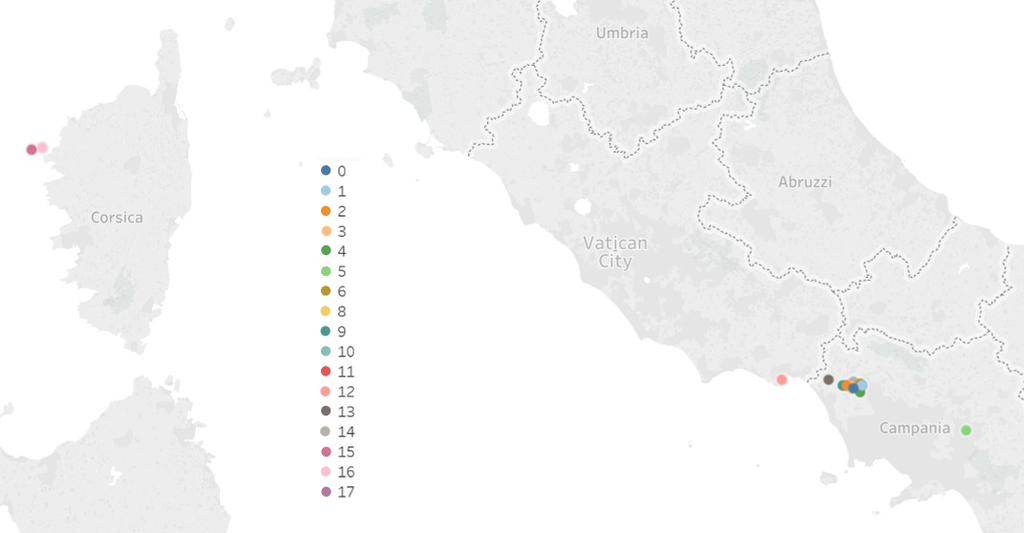

- Liczba producentów elektrowni:

```
## [1] 6
```

- Liczba modeli elektrowni:

```
## [1] 11
```

- Rozważany przedział czasowy:

```
## [1] "2012-01-02 02:00  -  2013-12-31 20:00"
```

- Przedział godzin w ciągu dnia:

```
## [1] "02:00  -  20:00"
```

- Podsumowanie wartości atrybutów:

| column_name | min | first_qu. | median | mean | third_qu. | max |
| --- | --- | --- | --- | --- | --- | --- |
| id | 1.000 | 9.964625e+04 | 1.585935e+05 | 1.527029e+05 | 2.175408e+05 | 276488.000 |
| id_location | 0.000 | 4.000000e+00 | 9.000000e+00 | 8.588235e+00 | 1.300000e+01 | 17.000 |
| id_model_norm | 0.000 | 1.670000e-01 | 2.080000e-01 | 2.426471e-01 | 2.920000e-01 | 0.750 |
| id_brand_norm | 0.000 | 8.300000e-02 | 1.670000e-01 | 1.519412e-01 | 1.670000e-01 | 0.417 |
| latitude_norm | 0.415 | 4.370000e-01 | 4.370000e-01 | 4.495294e-01 | 4.390000e-01 | 0.553 |
| longitude_norm | 0.154 | 6.200000e-01 | 6.240000e-01 | 5.711176e-01 | 6.300000e-01 | 0.691 |
| age_in_months_norm | 0.000 | 0.000000e+00 | 1.250000e-01 | 3.144706e-01 | 7.190000e-01 | 1.000 |
| year | 2012.000 | 2.012000e+03 | 2.012000e+03 | 2.012500e+03 | 2.013000e+03 | 2013.000 |
| day_of_year_norm | 0.000 | 2.520000e-01 | 5.010000e-01 | 5.011341e-01 | 7.510000e-01 | 1.000 |
| hour_of_day_norm | 0.000 | 2.220000e-01 | 5.000000e-01 | 5.000000e-01 | 7.780000e-01 | 1.000 |
| avg_ambient_temperature_norm | 0.045 | 2.120000e-01 | 3.480000e-01 | 3.721645e-01 | 5.300000e-01 | 0.818 |
| irradiating_norm | 0.000 | 0.000000e+00 | 3.500000e-02 | 1.086428e-01 | 2.030000e-01 | 0.710 |
| pressure_norm | 0.000 | 7.480000e-01 | 7.530000e-01 | 6.502293e-01 | 7.550000e-01 | 0.769 |
| wind_speed_norm | 0.000 | 4.200000e-02 | 6.700000e-02 | 7.664280e-02 | 1.030000e-01 | 0.696 |
| humidity_norm | 0.160 | 5.400000e-01 | 7.000000e-01 | 6.859729e-01 | 8.400000e-01 | 1.000 |
| icon_norm | 0.000 | 8.300000e-02 | 6.670000e-01 | 4.622642e-01 | 6.670000e-01 | 0.750 |
| dew_point_norm | 0.139 | 5.340000e-01 | 6.170000e-01 | 6.042651e-01 | 6.800000e-01 | 0.865 |
| wind_direction_norm | 0.000 | 3.060000e-01 | 4.800000e-01 | 4.525686e-01 | 6.600000e-01 | 0.769 |
| cloud_cover_norm | 0.000 | 2.400000e-01 | 3.100000e-01 | 3.598786e-01 | 5.100000e-01 | 1.000 |
| avg_ambient_temperature_i_norm | 0.009 | 7.300000e-02 | 1.110000e-01 | 1.215033e-01 | 1.250000e-01 | 0.983 |
| irradiating_i_norm | 0.108 | 2.170000e-01 | 2.200000e-01 | 2.220302e-01 | 2.220000e-01 | 1.000 |
| pressure_i_norm | 0.000 | 0.000000e+00 | 0.000000e+00 | 2.415000e-04 | 0.000000e+00 | 1.000 |
| wind_speed_i_norm | 0.000 | 3.700000e-02 | 3.800000e-02 | 3.852340e-02 | 3.900000e-02 | 1.000 |
| humidity_i_norm | 0.034 | 4.400000e-02 | 4.400000e-02 | 6.394150e-02 | 6.200000e-02 | 0.579 |
| dew_point_i_norm | 0.063 | 1.140000e-01 | 1.140000e-01 | 1.192467e-01 | 1.180000e-01 | 0.415 |
| wind_direction_i_norm | 0.000 | 3.360000e-01 | 3.360000e-01 | 3.454866e-01 | 3.390000e-01 | 1.000 |
| cloud_cover_i_norm | 0.000 | 1.960000e-01 | 1.960000e-01 | 2.059902e-01 | 1.980000e-01 | 1.000 |
| season_norm | 0.000 | 2.513661e-01 | 4.972678e-01 | 5.003862e-01 | 7.540984e-01 | 1.000 |
| altitude_norm | 0.111 | 4.190000e-01 | 5.630000e-01 | 5.453358e-01 | 6.790000e-01 | 0.884 |
| azimuth_norm | 0.128 | 2.960000e-01 | 4.260000e-01 | 4.548426e-01 | 6.350000e-01 | 0.818 |
| altitude_i_norm | 0.000 | 9.600000e-02 | 1.350000e-01 | 2.055020e-01 | 2.640000e-01 | 0.982 |
| azimuth_i_norm | 0.000 | 2.090000e-01 | 2.870000e-01 | 3.642815e-01 | 4.810000e-01 | 1.000 |
| pcnm_norm_1 | 0.000 | 3.770000e-01 | 3.780000e-01 | 4.223529e-01 | 3.800000e-01 | 1.000 |
| pcnm_norm_2 | 0.000 | 2.500000e-01 | 3.770000e-01 | 3.537647e-01 | 4.220000e-01 | 0.972 |
| pcnm_norm_3 | 0.000 | 5.510000e-01 | 6.050000e-01 | 6.044706e-01 | 7.300000e-01 | 1.000 |
| pcnm_norm_4 | 0.000 | 3.630000e-01 | 5.310000e-01 | 5.189412e-01 | 6.340000e-01 | 1.000 |
| pcnm_norm_5 | 0.000 | 3.310000e-01 | 4.270000e-01 | 4.164706e-01 | 4.620000e-01 | 1.000 |
| pcnm_norm_6 | 0.000 | 3.390000e-01 | 4.930000e-01 | 4.940588e-01 | 4.930000e-01 | 1.000 |
| pcnm_norm_7 | 0.000 | 3.100000e-02 | 5.200000e-02 | 1.141765e-01 | 1.140000e-01 | 1.000 |
| pcnm_norm_8 | 0.000 | 2.040000e-01 | 4.120000e-01 | 4.033529e-01 | 5.110000e-01 | 1.000 |
| pcnm_norm_9 | 0.000 | 5.270000e-01 | 5.320000e-01 | 5.371176e-01 | 6.000000e-01 | 1.000 |
| pcnm_norm_10 | 0.000 | 5.530000e-01 | 6.190000e-01 | 6.276471e-01 | 7.170000e-01 | 1.000 |
| pcnm_norm_11 | 0.000 | 2.570000e-01 | 3.270000e-01 | 3.236471e-01 | 3.270000e-01 | 1.000 |
| pcnm_norm_12 | 0.000 | 7.480000e-01 | 7.600000e-01 | 7.567647e-01 | 8.840000e-01 | 1.000 |
| pcnm_norm_13 | 0.137 | 6.140000e-01 | 6.140000e-01 | 6.500588e-01 | 7.380000e-01 | 1.000 |
| pcnm_norm_14 | 0.000 | 4.320000e-01 | 4.730000e-01 | 4.892941e-01 | 5.300000e-01 | 1.000 |
| pcnm_norm_15 | 0.000 | 6.120000e-01 | 6.140000e-01 | 5.709412e-01 | 6.150000e-01 | 1.000 |
| sun_radiation_norm | 0.000 | 0.000000e+00 | 7.600000e-02 | 1.802379e-01 | 3.210000e-01 | 1.000 |
| sun_radiation_i_norm | -0.025 | 1.580000e-01 | 1.940000e-01 | 1.974993e-01 | 2.140000e-01 | 1.006 |
| energy_kwh_norm | 0.000 | 0.000000e+00 | 4.800000e-02 | 1.676556e-01 | 3.290000e-01 | 1.000 |

- Początek zbioru:

| id | id_location | id_model_norm | id_brand_norm | latitude_norm | longitude_norm | age_in_months_norm | year | day_of_year_norm | hour_of_day_norm | date_time | avg_ambient_temperature_norm | irradiating_norm | pressure_norm | wind_speed_norm | humidity_norm | icon_norm | dew_point_norm | wind_direction_norm | cloud_cover_norm | avg_ambient_temperature_i_norm | irradiating_i_norm | pressure_i_norm | wind_speed_i_norm | humidity_i_norm | dew_point_i_norm | wind_direction_i_norm | cloud_cover_i_norm | season_norm | altitude_norm | … |
| --- | --- | --- | --- | --- | --- | --- | --- | --- | --- | --- | --- | --- | --- | --- | --- | --- | --- | --- | --- | --- | --- | --- | --- | --- | --- | --- | --- | --- | --- | --- |
| 97772 | 0 | 0 | 0.333 | 0.436 | 0.626 | 0.719 | 2012 | 0.003 | 0.000 | 1/2/2012 2:00 | 0.212 | 0.000 | 0.000 | 0.054 | 0.82 | 0.083 | 0.436 | 0.557 | 0.00 | 0.119 | 0.220 | 0 | 0.038 | 0.046 | 0.114 | 0.422 | 0.320 | 0.9836066 | 0.117 | … |
| 5404 | 0 | 0 | 0.333 | 0.436 | 0.626 | 0.719 | 2012 | 0.003 | 0.056 | 1/2/2012 3:00 | 0.212 | 0.000 | 0.762 | 0.020 | 0.85 | 0.083 | 0.434 | 0.441 | 0.11 | 0.115 | 0.220 | 0 | 0.053 | 0.044 | 0.114 | 0.348 | 0.214 | 0.9836066 | 0.131 | … |
| 160687 | 0 | 0 | 0.333 | 0.436 | 0.626 | 0.719 | 2012 | 0.003 | 0.111 | 1/2/2012 4:00 | 0.212 | 0.000 | 0.762 | 0.086 | 0.84 | 0.083 | 0.431 | 0.450 | 0.11 | 0.111 | 0.220 | 0 | 0.038 | 0.093 | 0.114 | 0.525 | 0.196 | 0.9836066 | 0.175 | … |
| 240621 | 0 | 0 | 0.333 | 0.436 | 0.626 | 0.719 | 2012 | 0.003 | 0.167 | 1/2/2012 5:00 | 0.212 | 0.000 | 0.762 | 0.086 | 0.70 | 0.083 | 0.440 | 0.471 | 0.11 | 0.108 | 0.220 | 0 | 0.037 | 0.041 | 0.114 | 0.456 | 0.210 | 0.9836066 | 0.231 | … |
| 232899 | 0 | 0 | 0.333 | 0.436 | 0.626 | 0.719 | 2012 | 0.003 | 0.222 | 1/2/2012 6:00 | 0.212 | 0.002 | 0.762 | 0.086 | 0.82 | 0.083 | 0.430 | 0.493 | 0.11 | 0.106 | 0.218 | 0 | 0.038 | 0.076 | 0.114 | 0.409 | 0.196 | 0.9836066 | 0.290 | … |
| 104791 | 0 | 0 | 0.333 | 0.436 | 0.626 | 0.719 | 2012 | 0.003 | 0.278 | 1/2/2012 7:00 | 0.212 | 0.011 | 0.762 | 0.086 | 0.80 | 0.000 | 0.431 | 0.471 | 0.11 | 0.104 | 0.216 | 0 | 0.037 | 0.044 | 0.145 | 0.428 | 0.208 | 0.9836066 | 0.350 | … |
| 241107 | 0 | 0 | 0.333 | 0.436 | 0.626 | 0.719 | 2012 | 0.003 | 0.333 | 1/2/2012 8:00 | 0.212 | 0.007 | 0.762 | 0.075 | 0.76 | 0.000 | 0.479 | 0.493 | 0.11 | 0.102 | 0.221 | 0 | 0.037 | 0.047 | 0.114 | 0.336 | 0.196 | 0.9836066 | 0.409 | … |
| 128567 | 0 | 0 | 0.333 | 0.436 | 0.626 | 0.719 | 2012 | 0.003 | 0.389 | 1/2/2012 9:00 | 0.212 | 0.004 | 0.762 | 0.066 | 0.58 | 0.000 | 0.488 | 0.420 | 0.00 | 0.102 | 0.217 | 0 | 0.038 | 0.044 | 0.118 | 0.337 | 0.199 | 0.9836066 | 0.465 | … |
| 241130 | 0 | 0 | 0.333 | 0.436 | 0.626 | 0.719 | 2012 | 0.003 | 0.444 | 1/2/2012 10:00 | 0.348 | 0.018 | 0.762 | 0.075 | 0.56 | 0.000 | 0.514 | 0.493 | 0.00 | 0.142 | 0.249 | 0 | 0.037 | 0.123 | 0.149 | 0.336 | 0.198 | 0.9836066 | 0.517 | … |
| 147873 | 0 | 0 | 0.333 | 0.436 | 0.626 | 0.719 | 2012 | 0.003 | 0.500 | 1/2/2012 11:00 | 0.348 | 0.007 | 0.762 | 0.064 | 0.53 | 0.000 | 0.515 | 0.514 | 0.00 | 0.144 | 0.223 | 0 | 0.039 | 0.149 | 0.115 | 0.337 | 0.263 | 0.9836066 | 0.563 | … |

## 8. Szczegółowa analiza wartości atrybutów - wykresy rozkładu wartości atrybutów

Poniżej prezentowane są rozkłady wartości poszczególnych atrybutów zbioru danych.

#### Dane techniczne elektrowni:

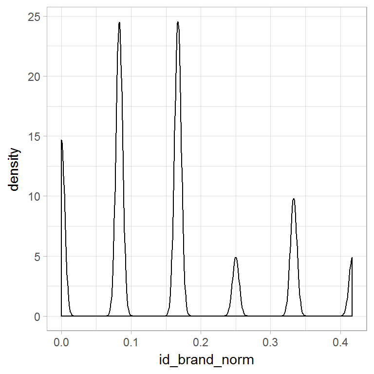

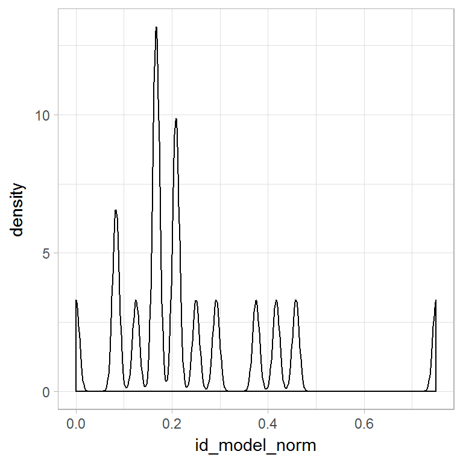

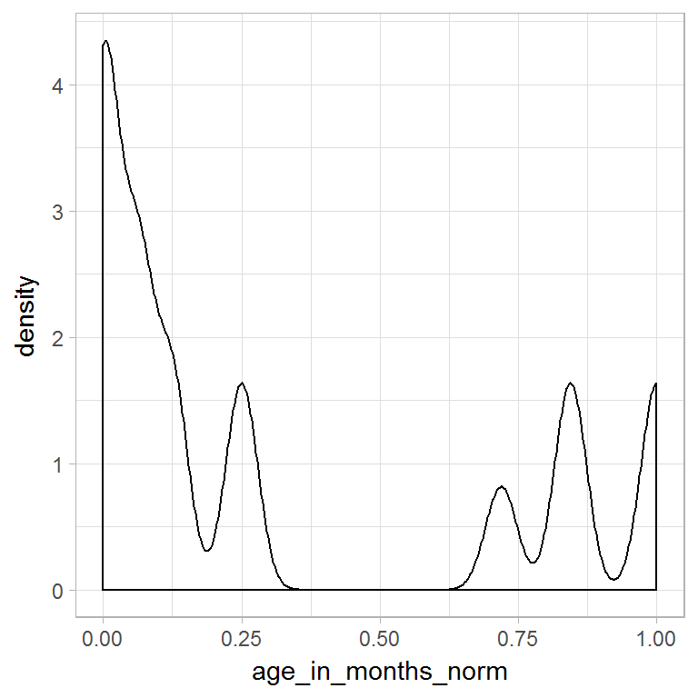

#### Lokalizacja elektrowni:

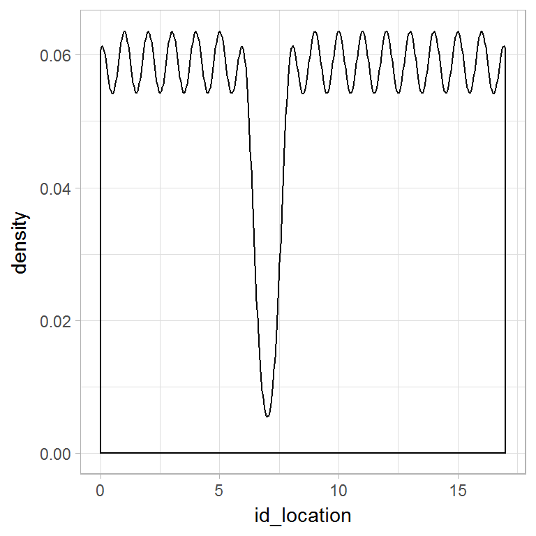

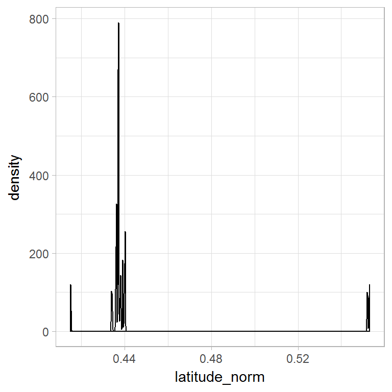

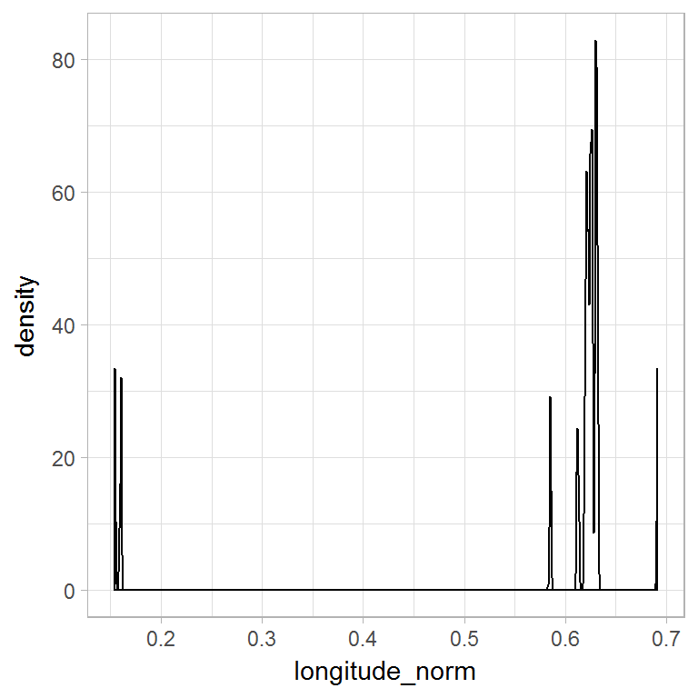

#### Czas pomiaru:

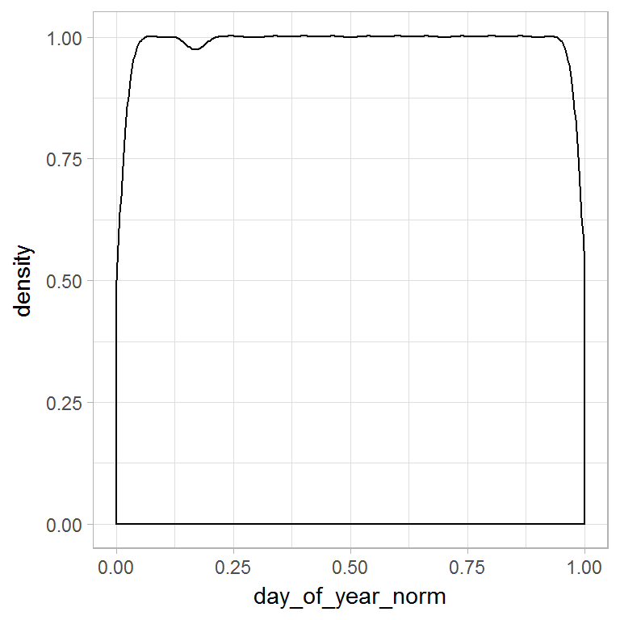

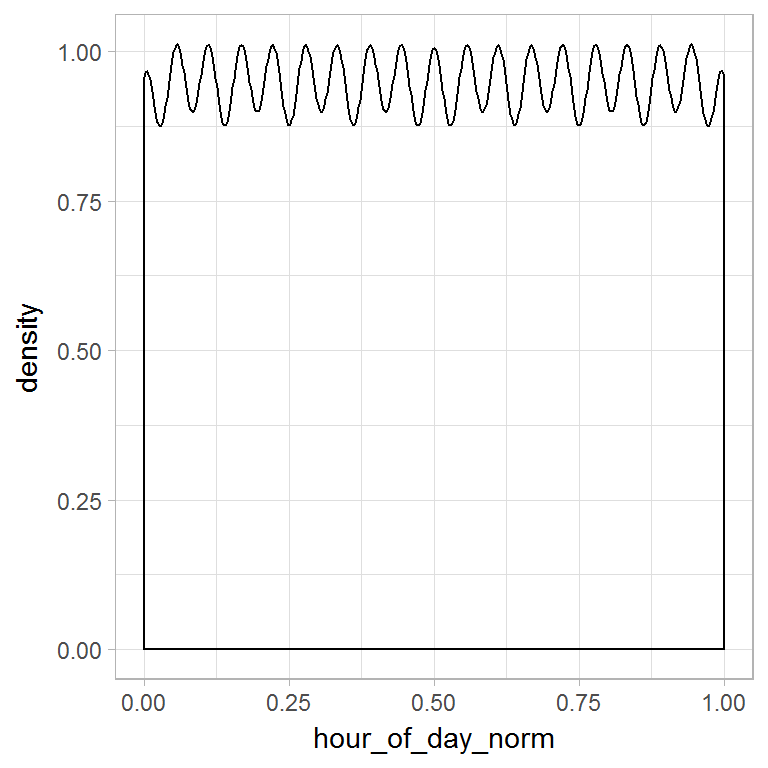

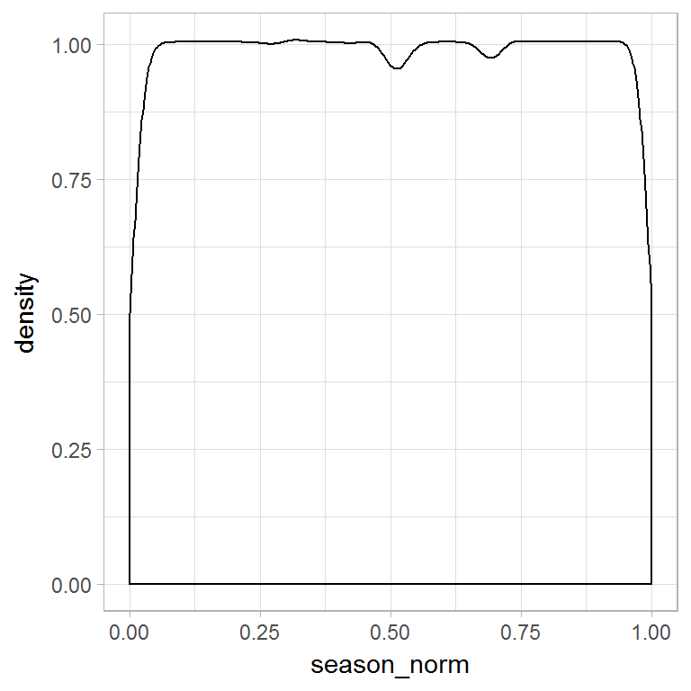

#### Dane pogodowe w momencie pomiaru:

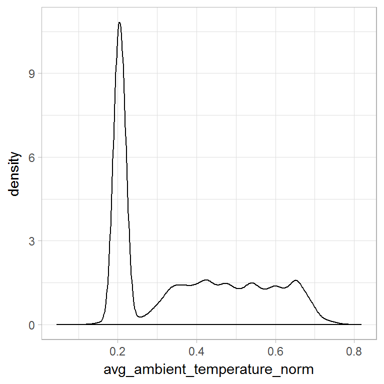

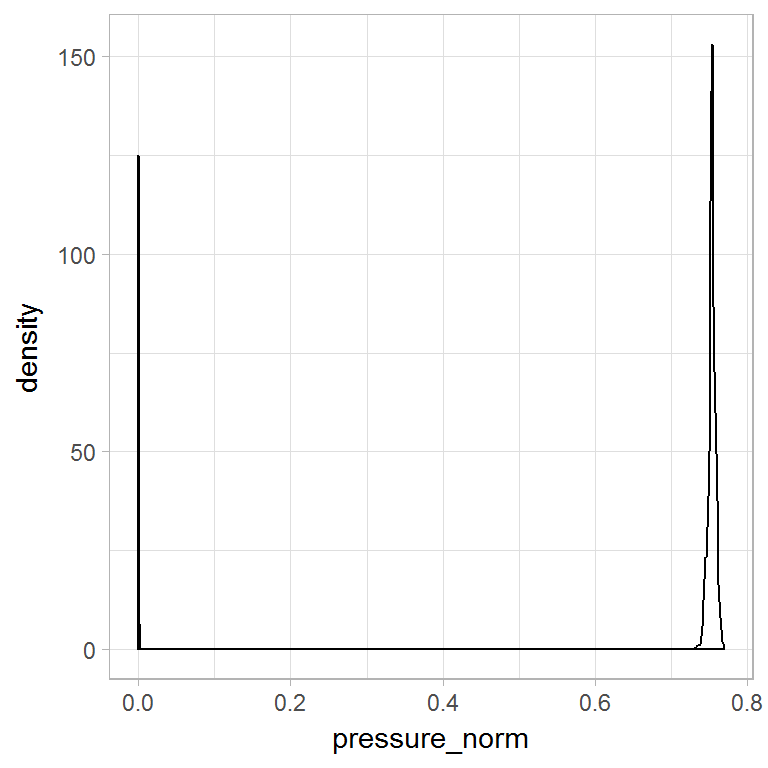

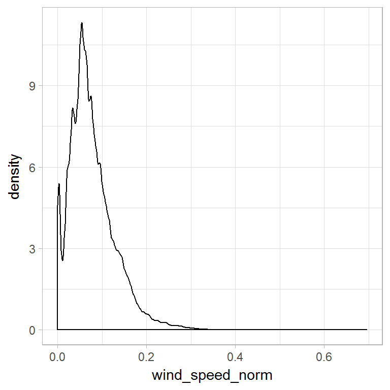

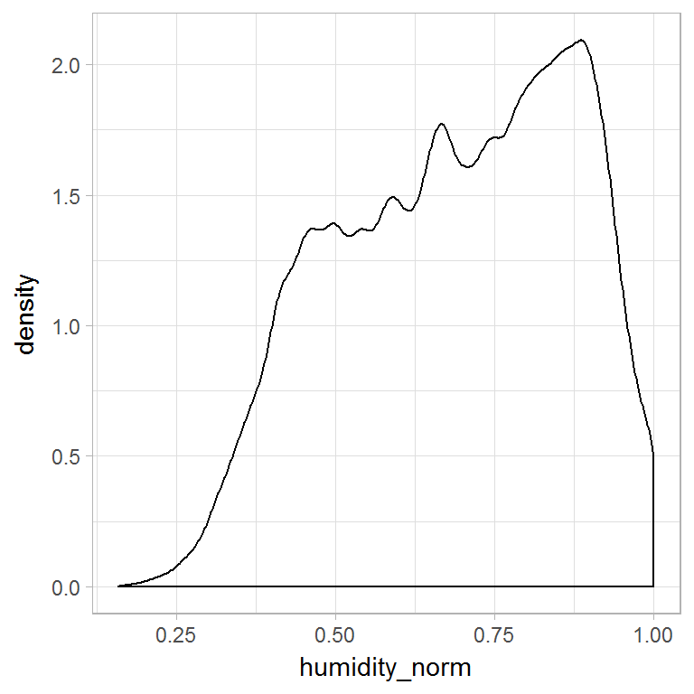

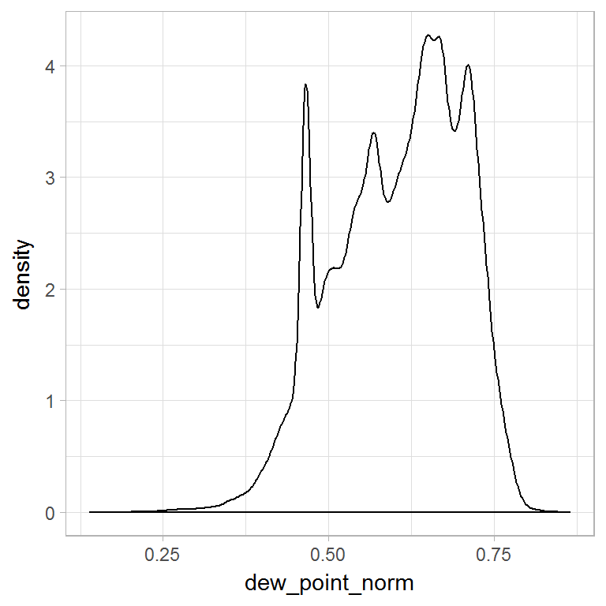

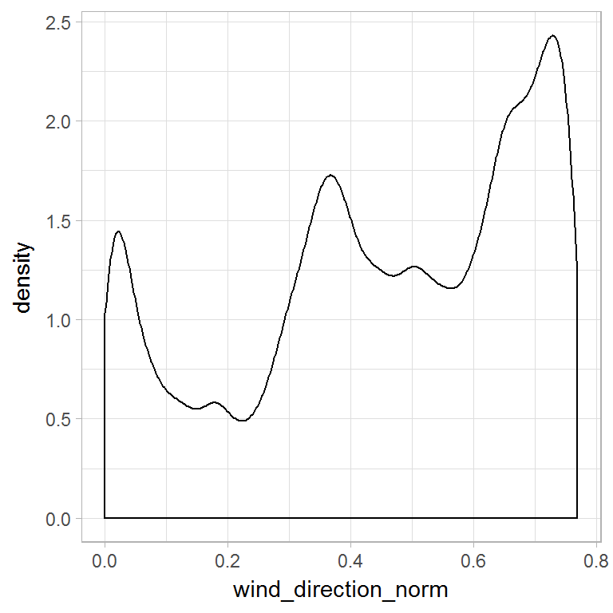

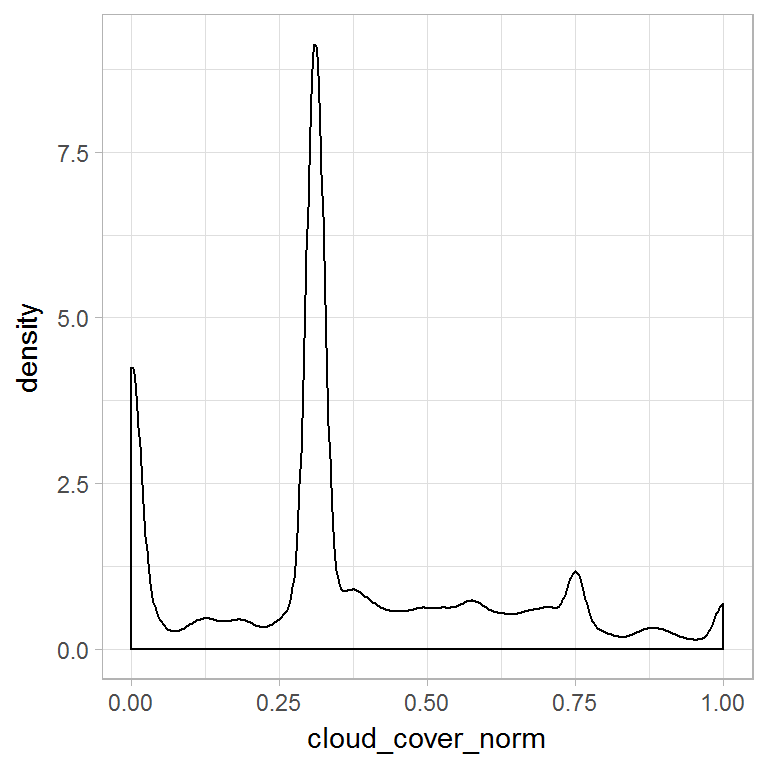

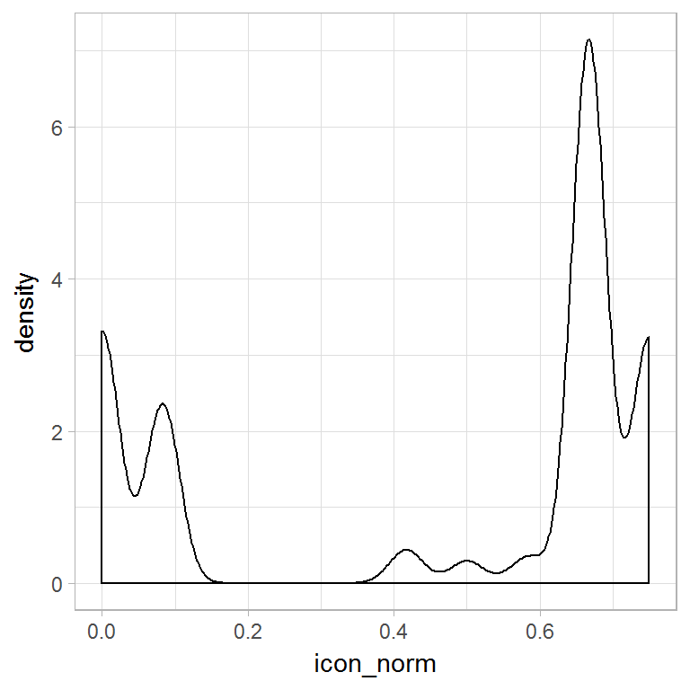

#### Wartości parametru statystycznego Morana I danych pogodowych w momencie pomiaru:

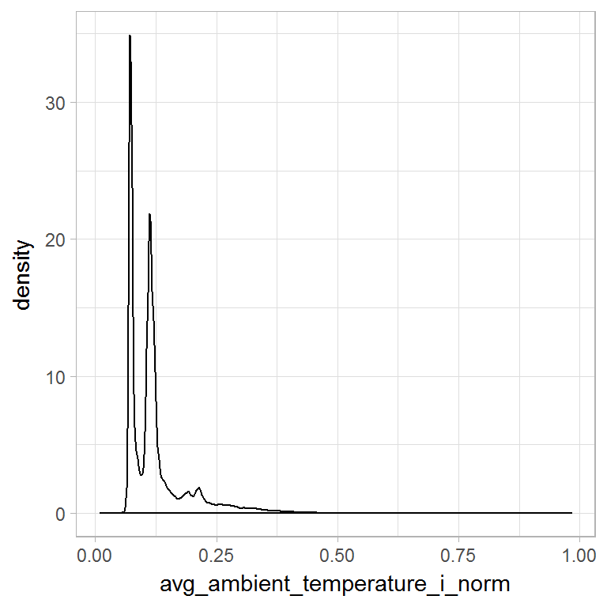

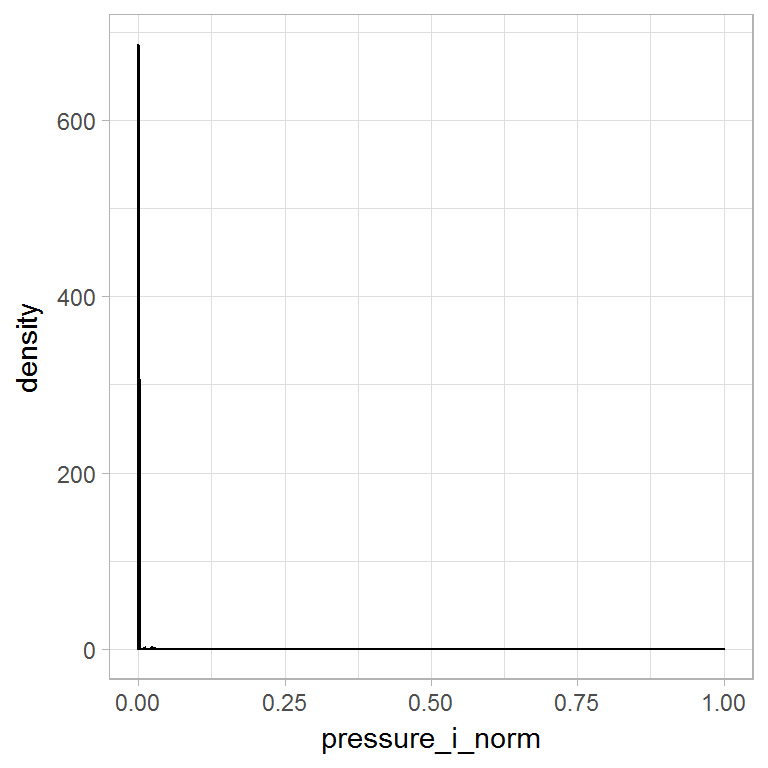

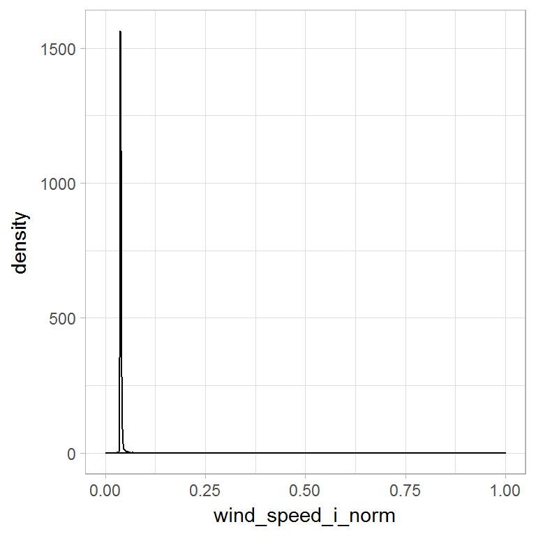

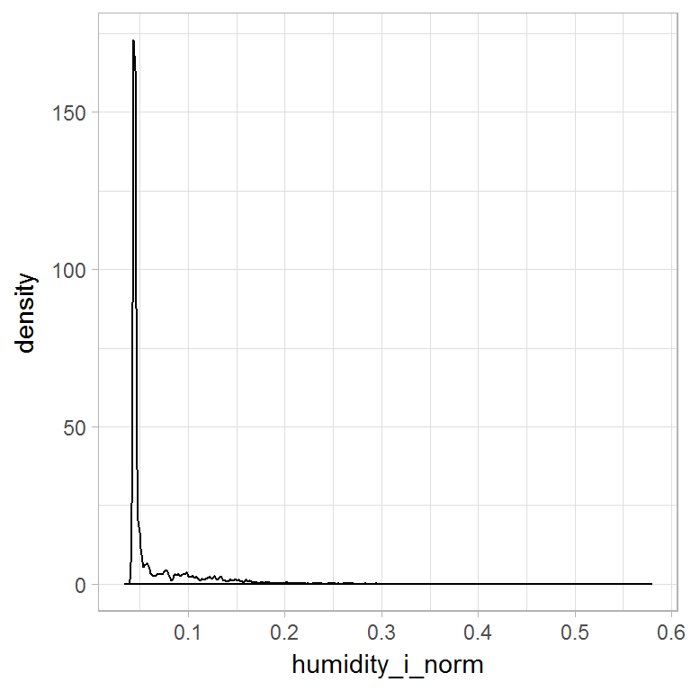

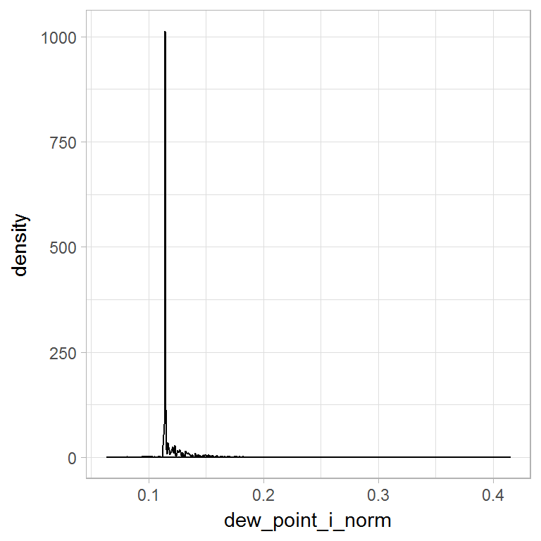

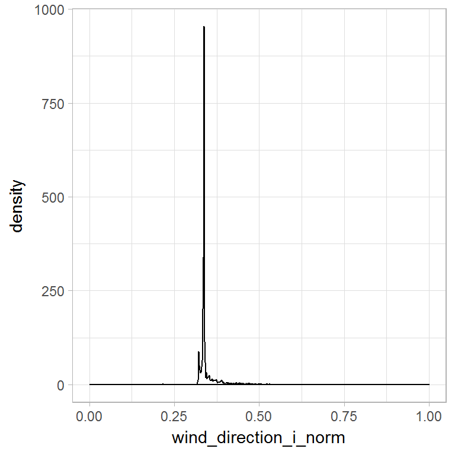

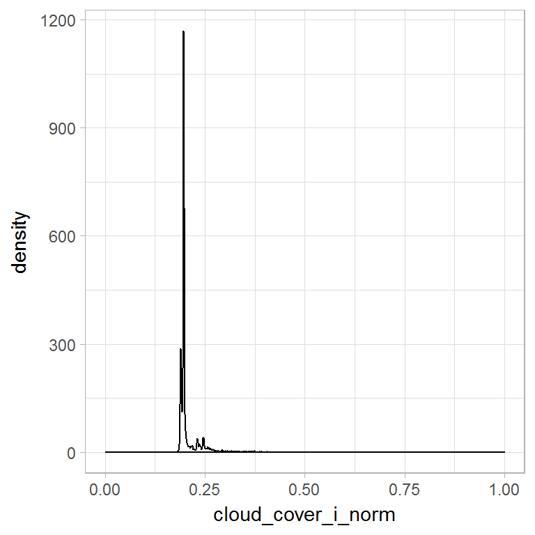

#### Parametry słońca w momencie pomiaru:

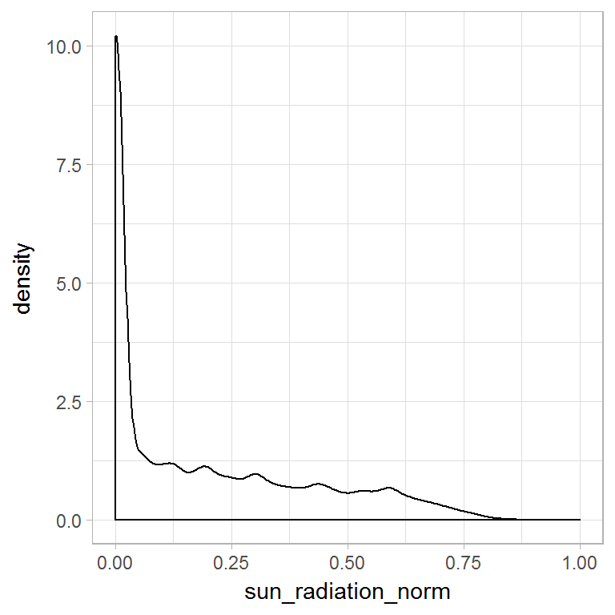

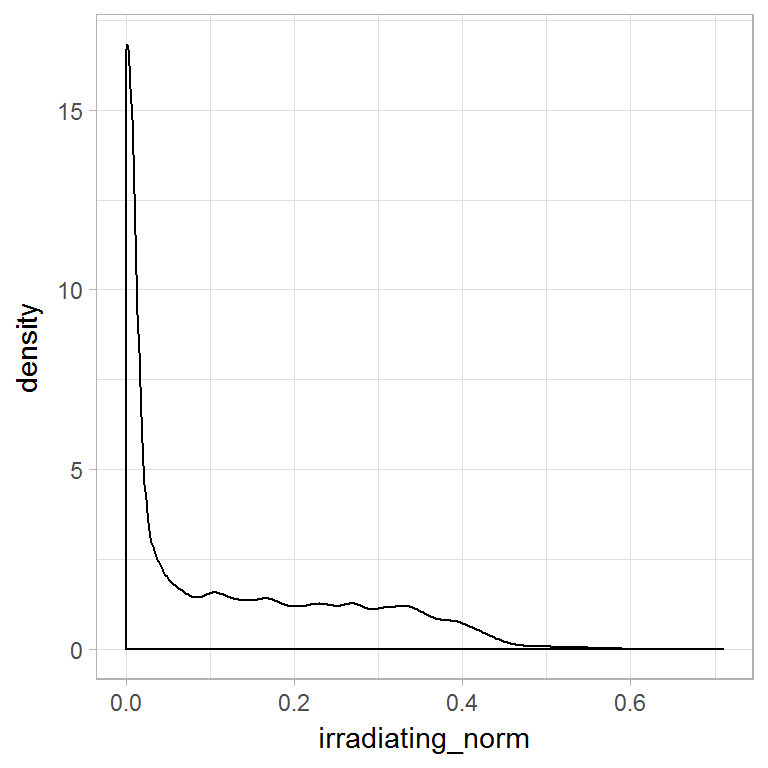

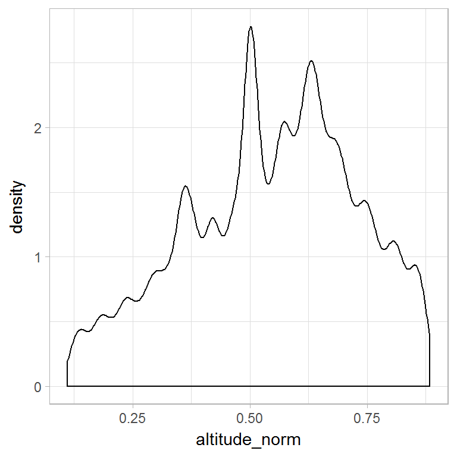

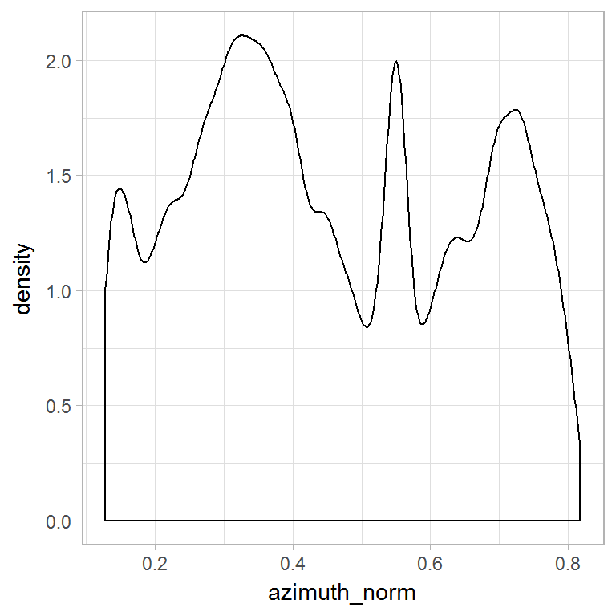